# Final Project

Jashon Newlun

# WW2 Weather - Predicting Maximum Temperature

This data set was found from kaggle and has approximately 120k observations. These observations were taken in many different places during the WW2 period. precipitation, mean, min, and max temp, as well as wind speed and snowfall were all collected.

## Model Selection

I will take you through parts of the model selection, or what specifically I thought of while I was addressing the data. Typically, our final model would be put here bust because it turns out to be a loess curve, there is not a model to write. We are going to predict the high temperature for a day based on other variables.

```r
library(tidyverse)
library(ResourceSelection)
library(mosaic)
library(pander)
library(ggthemes)
library(MASS)
library(car)

weainfo <- read_csv("../../data/Summary of Weather.csv")

ww2 <- read.csv("../../data/Summary of Weather.csv", header = TRUE) %>%
  dplyr::select(-PoorWeather,-SNF,-SND,-FT,-FTI,-FB,-ITH,-TSHDSBRSGF,-SD3,-RHX,-RHN,-RVG,-WTE, -WindGustSpd, -SPD, -DR, -PGT) %>%
  filter(PRCP != "T") %>%
  mutate(PRCP = as.numeric(PRCP))
```

It seems as though there may be a correlation between month and the high temp.

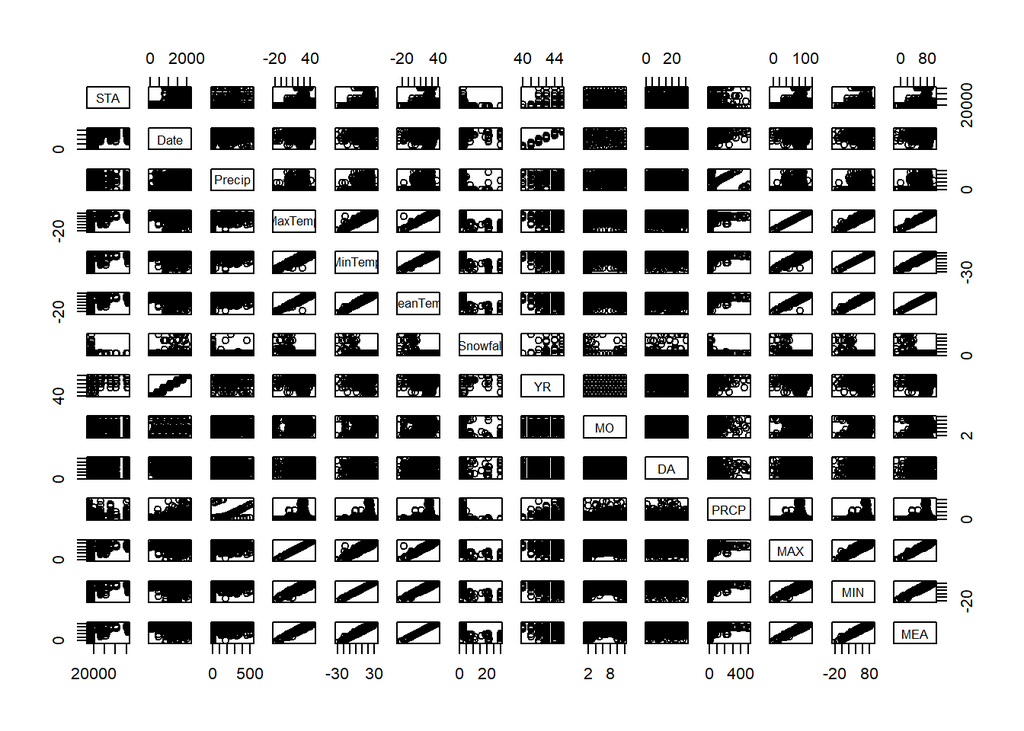

```r
#pairs(ww2[ ,1:5])
keep <- sample(1:nrow(ww2),round(.02*nrow(ww2)))
dat <- ww2[keep, ]
pairs(dat)
```

```r
#Month seems to have strong quadrati relationship


lm1 <- lm(MeanTemp ~ MO + I(MO^3), data = dat)
b <- lm1$coefficients
pander(summary(lm1))
```

|  | Estimate | Std. Error | t value | Pr(>\|t\|) |
| --- | --- | --- | --- | --- |
| **(Intercept)** | 16.91 | 0.5706 | 29.63 | 9.03e-161 |
| **MO** | 1.605 | 0.1387 | 11.58 | 4.556e-30 |
| **I(MO^3)** | -0.009724 | 0.0008365 | -11.62 | 2.732e-30 |

Fitting linear model: MeanTemp ~ MO + I(MO^3)

| Observations | Residual Std. Error | $R^2$ | Adjusted $R^2$ |
| --- | --- | --- | --- |
| 2046 | 8.085 | 0.06398 | 0.06306 |

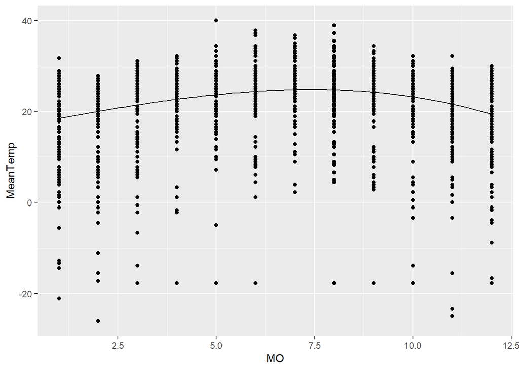

```r
dat %>%
  ggplot(aes(x = MO, y = MeanTemp)) +
  geom_point() +
  stat_function(fun = function(x)(b[1] + b[2]*x + b[3]*x^3))
```

The month variable is very significant, and the graphic shows that there is reason to believe that one can use month to describe the data, however, our R^2 is quite low, and our prediction value is lacking because the variance is so large. Lets try adding year to the data.

```r
#year seems to have a quadratic relationship as well

lm2 <- lm(MeanTemp ~ MO + I(MO^3) + I(YR^2), data = dat)
pander(summary(lm2))
```

|  | Estimate | Std. Error | t value | Pr(>\|t\|) |
| --- | --- | --- | --- | --- |
| **(Intercept)** | 14.75 | 3.635 | 4.058 | 5.142e-05 |
| **MO** | 1.608 | 0.1388 | 11.59 | 3.991e-30 |
| **I(MO^3)** | -0.009719 | 0.0008367 | -11.62 | 3.009e-30 |
| **I(YR^2)** | 0.001108 | 0.001843 | 0.6009 | 0.548 |

Fitting linear model: MeanTemp ~ MO + I(MO^3) + I(YR^2)

| Observations | Residual Std. Error | $R^2$ | Adjusted $R^2$ |
| --- | --- | --- | --- |
| 2046 | 8.086 | 0.06414 | 0.06277 |